# PCA

INFO 521 · Module 7 — Principal Component Analysis & Course Synthesis

Greg Chism

College of Information Science · University of Arizona

August 2026

## Learning outcomes

By the end of Module 7 you should be able to:

1. **Compute PCA** — center, covariance, eigendecomposition — from scratch.
2. **State both views** — maximum variance ⟺ minimum reconstruction error.
3. **Read variance explained** ($\lambda_k / \sum_j \lambda_j$) and choose a number of components with a scree plot.
4. **Interpret components on NHANES** — and state PCA’s limits honestly.

## The question: which directions matter?

Six NHANES features per patient — but are they six *independent* pieces of information?

- BMI and waist circumference track each other at $r \approx 0.90$ — nearly one measurement wearing two names.
- **PCA asks**: find new axes — **principal components** — that are *uncorrelated*, ordered by how much variance each carries.

$$\mathbf{z}_n = \mathbf{V}^{\!\top} \mathbf{x}_n
\qquad
\text{with } \mathbf{V} = [\mathbf{v}_1 \cdots \mathbf{v}_D] \text{ orthonormal.}$$

Keep the first $K \ll D$ coordinates: a **shorter description** of every patient, losing as little as possible.

## Center first, then covariance

PCA is a statement about **spread around the mean**, so:

1. **Center** each feature ($\mathbf{x}_n \leftarrow \mathbf{x}_n - \bar{\mathbf{x}}$) — otherwise the first component just points at the mean.
2. **Standardize** when units differ (they do here — years, kg/m², cm, mg/dL, %): variance is unit-squared, and PCA maximizes it. m6b’s scaling lesson, verbatim.
3. Form the **sample covariance** $\ \mathbf{C} = \tfrac{1}{N-1}\mathbf{X}^{\!\top}\mathbf{X}$ (centered $\mathbf{X}$) — the object m3b promised would return.

$$\mathbf{C}\,\mathbf{v}_k = \lambda_k\,\mathbf{v}_k
\qquad
\lambda_1 \ge \lambda_2 \ge \cdots \ge \lambda_D \ge 0$$

**Eigenvectors** = the new axes; **eigenvalues** = the variance each carries.

## Two views, one solution

**View 1 — max variance.** Find the unit direction with the most spread:

$$\max_{\lVert\mathbf{v}\rVert = 1}\ \mathbf{v}^{\!\top}\mathbf{C}\,\mathbf{v}
\;\;\Longrightarrow\;\; \mathbf{v} = \mathbf{v}_1\ (\text{top eigenvector}).$$

**View 2 — min reconstruction.** Project onto $K$ directions and rebuild; choose directions minimizing the squared error:

$$\min_{\mathbf{V}_K}\ \sum_{n=1}^{N}
\bigl\lVert \mathbf{x}_n - \mathbf{V}_K^{\phantom{\top}}\!\mathbf{V}_K^{\!\top}\mathbf{x}_n \bigr\rVert_2^2
\;\;\Longrightarrow\;\; \text{the same top-}K\text{ eigenvectors.}$$

Variance kept + reconstruction error = total variance (a constant): maximizing one **is** minimizing the other. Least squares (m1b’s projection!) closes the course as it opened it.

## PC1 on the adiposity plane

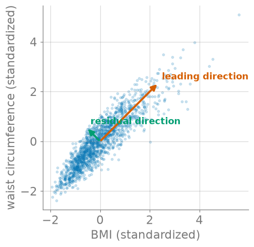

Figure 1: The (BMI, waist) plane, r ≈ 0.90: almost all spread lies along one shared direction (vermillion) — the redundancy PCA is built to remove.

## All six features: the scree plot

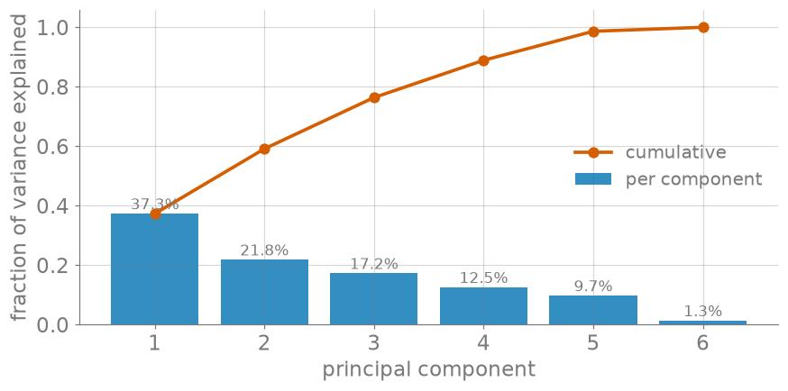

Figure 2: PCA on all six standardized features: PC1 carries 37.3%, PC1–2 59.1%, PC1–3 76.4% — and PC6 a residual 1.3% (the BMI/waist redundancy, found).

- **Variance explained**: $\lambda_k \big/ \sum_j \lambda_j$.
- The near-zero PC6 (1.3%) is the algebra’s way of saying *one of these six numbers is almost redundant* — we already knew which pair.

## What do the components mean?

Loadings of the first two components (signs fixed by convention):

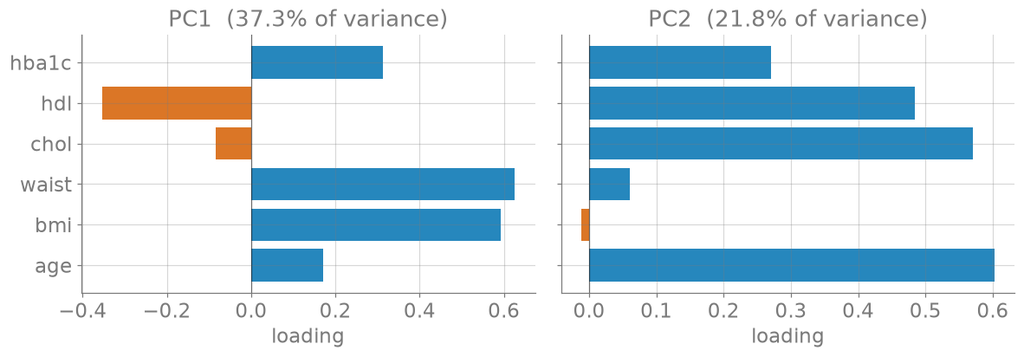

Figure 3: Loadings: PC1 ≈ an adiposity/metabolic axis (BMI + waist + HbA1c, HDL opposing); PC2 ≈ an age–cholesterol axis.

## Choosing K, and what “explained” buys

- **Scree / elbow** — the m6b judgment call again: after PC3 the gains flatten; 2–3 components describe these patients reasonably.
- **Threshold** — “keep 90%” → here $K = 5$ (cumulative 98.7% at 5, 88.9% at 4).
- **Downstream use** — if the scores feed a supervised model, choose $K$ by **cross-validation** on that model (m2a closes the loop).

Compression is a *tool*, not a truth: variance explained is measured on $\mathbf{X}$ — no label ever voted.

## Limitations — said plainly

- **Linear**: components are straight axes; a curved manifold (spirals, clusters on a ring) is invisible to them.
- **Variance ≠ usefulness**: PCA never saw the label. The direction that predicts hypertension may hide in a low-variance component — m6b’s cluster-vs-label caution, transposed to axes.
- **Scale-dependent**: standardize or the units choose your components (m6b).
- **Interpretability is a gift, not a guarantee**: PC1 happened to be clinically readable here; rotated blends often aren’t.

## Live demo: the PCA explorer

Rotate the candidate axis in the week06 tool and watch variance-captured and reconstruction-error trade places — the two views of one solution.

## Explorer — static fallback

*The iframe above does not print or export to PDF; this snapshot stands in.*

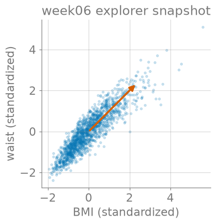

Figure 4: Static fallback: the leading direction on the adiposity plane (used in print / PDF).

## The course, in one arc

One dataset, five ways of seeing — each module’s answer became the next one’s question:

|  | The move | The object |
| --- | --- | --- |
| **Loss** (M1–M2) | minimize $\mathcal{L}$; control flexibility | $\hat{\mathbf{w}} = (\mathbf{X}^{\!\top}\mathbf{X})^{-1}\mathbf{X}^{\!\top}\mathbf{y}$ |
| **Likelihood** (M3) | model the noise; maximize $\ell$ | same $\hat{\mathbf{w}}$ + $\hat{\sigma}^2$ + $\mathrm{Cov}[\hat{\mathbf{w}}]$ |
| **Posterior** (M4) | believe, then update | $\mathcal{N}(\mathbf{m}_N, \mathbf{S}_N)$ — Part 1’s endpoint |
| **Approximation** (M5) | when conjugacy breaks, approximate | Laplace $\mathbf{A}^{-1}$; Metropolis draws |
| **Discovery** (M6–M7) | drop the labels | clusters; principal axes — described, not diagnosed |

And one object followed you the whole way: $\mathbf{X}^{\!\top}\mathbf{X}$ — loss bowl, likelihood curvature, Fisher information, posterior precision, covariance. **That’s the course.**